# First notebook

Helen Ridout

11 December 2020

# This is a Heading

## Inline text formating

to make text bold use **double asterisks** or **double underscore**

to make text italic use *asterisks* or *underscore*

to make text superscript use <sup>pointyuparrows</sup>

to make text subscript use <sub>tilde</sub>

to mark text as inlike code use `backticks`

to use strikethrough use double tilde

## Line breaks

To separate lines

use back slashes

# Links + lists

Linking to website put the link in [square brackets, followed by the link in ()](https://www.youtube.com/watch?v=dQw4w9WgXcQ)

Link to first heading - for this to work, the link_to_header must be in {} next to the header with one #.

## Footnotes

To indicate a footnote use[^1] and a second footnote[^2]

## Lists

Ordered lists (for sublists use 4 spaces to indent item)

1. Golden Oriole
2. Cat
3. Black Blood
   1. Enhanced Black Blood
4. White Honey

Unordered lists (*, +, -):

- School of the Bear
- School of the Wolf
  - School of the Cat
- School of the Viper

Task list

Task lists can be done in the following syntax:

- [ ] an unchecked task list item
- [x] a checked task list item

# Inserting figures

put figures you want in an img folder of the project you’re working on.

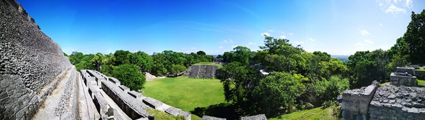

Image caption - Xunantunich

| Column 1 | Column 2 |
| --- | --- |
| Obi-Wan | Master |
| Anakin | Padawan |

| Left align | Center align | Right align |
| --- | --- | --- |
| Item 1,1 | Item 1,2 | Item 1,3 |
| Item 2,1 | Item 2,2 | Item 2,3 |

For tables with more than two columns, include these : in the way seen above. For big tables, these are not really particularly efficient or useful.

# Blocks

## Text Blocks

> For blocks, use a right-pointing angle bracket

> to make it more than one line, always start with the bracket

## Code blocks

Use three backticks (```) for enclosing things in a code block

```
print("Hello World!")
x = c(1,2,3)
print(x)
```

# Creating a table of contents

Go to the top of the document, as it applies to all the page. Use this code at the top of the page:

```
output:
    html_document:
        toc: true
```

Can change the depth of the heading with

```
toc_depth: 4
```

This code above displays the table of contents at the top of the page, to get it as a sidebar that moves as you scroll:

```
toc_float: true
```

So the total code is:

```
output:
    html_document:
        toc: true
        toc_depth: 4
        toc_float: true
```

Be precise with the spacing in this. ALSO be aware with the floating sidebar of a contents table, it is very sensitive to the hashes on the headings, so make sure that all the headings you want are visible.

# References examples

Put references into a text file in the same sort of format as visible in the one on here. Upload the references to the R session.  
Go into the yaml section and add under the date:

```
bibliography: references.bib
link-citation: yes
```

Citation to a paper Cardona et al. (2019) and Cardona (2014)  
Then put the references at the bottom of the doc with the # key.

# Challenges 1 + 2

## 1,500 scientists lift the lid on reproducibility

##### 25 May 2016

## Survey sheds light on ‘crisis’ rocking research

**More than 70% of researchers have tried and failed to reproduce other scientist’s experiments**, and more than half have failed to reproduce their own experiments. Those are some of the telling figures that emerged from *Nature*’s survey of 1,576 researchers who took a brief online questionnaire on reproducibility in research.

The data reveal sometimes-contradictory attitudes towards reproducibility. Although 52% of those surveyed agree that there is a significant ‘crisis’ of reproducibility, less than 31% think that failure to reproduce published results means that the result is probably wrong, and most say that they still trust the published literature.

(to do this in a new website, put the first three headings under ‘challenge’ in the title, author and date sections respectively at the top of the page.)

#### Challenge 2

[figure not shown]

### The Survey

In the survey[^3] respondents were asked to rate 11 different approaches to improving reproducibilty in science. Below is the list order by the most highly rated:

- Better understanding of statistics
- Better mentoring/supervision
- More robust design
- Better teaching
- More within-lab validation
- Incentives for better practice
- Incentives for formal reproduction
- More external-lab validation
- More time for mentoring
- Journals enforcing standards
- More time checking notebooks

# References

Cardona, Alexia, Felix R. Day, John R.B. Perry, Marie Loh, Audrey Y. Chu, Benjamin Lehne, Dirk S. Paul, et al. 2019. “Epigenome-Wide Association Study of Incident Type 2 Diabetes in a British Population: EPIC-Norfolk Study.” *Diabetes*. American Diabetes Association. https://doi.org/10.2337/db18-0290.

Cardona, Luca AND Antao, Alexia AND Pagani. 2014. “Genome-Wide Analysis of Cold Adaptation in Indigenous Siberian Populations.” *PLOS ONE* 9 (5). Public Library of Science: 1–11. https://doi.org/10.1371/journal.pone.0098076.

[^1]: this is the first footnote
[^2]: this is the second
[^3]: The survey can be downloaded [here](https://www.nature.com/news/1-500-scientists-lift-the-lid-on-reproducibility-1.19970)